# tarea3

```python
# Import required libraries
import pandas as pd
from sklearn.datasets import load_iris
from factor_analyzer import FactorAnalyzer
import matplotlib.pyplot as plt
import numpy as np



# función para generar el analisis factorial

def perform_factor_analysis(datos, num_factors,tipo):

    # Inicializar el objeto FactorAnalyzer con el número de factores especificado
    fa = FactorAnalyzer(n_factors=num_factors,rotation=tipo,method="ml")

    # Ajustar el modelo a los datos
    fa.fit(datos)

    # Obtener las cargas factoriales
    cargas= fa.loadings_

    # obtener las comunalidades
    comunidad = fa.get_communalities()

    # obtener las varianzas
    var, var_exp = fa.get_eigenvalues()
    var = var[0:num_factors]
    var = np.append(var,sum(var))
    var_por = var / sum(var)


    # Crear un DataFrame con los resultados

    datacargas=pd.DataFrame(cargas,index=datos.columns,columns=[f'Factor_{i+1}' for i in range(num_factors)])
    #datacargas["Comunidades"]=pd.DataFrame(comunidad,index=datos.columns,columns=["Comunidades"])
    datacargas["Comunalidades"]=comunidad
    datacargas.loc['Varianza']= var
    datacargas.loc['%Var'] = var_por
    return datacargas
```

Utilice python para programar una función que reciba una base de datos y un número de factores y devuelva un dataframe con las cargas factoriales de cada variable y las comunalidades utilizando:

a) Utilice un procedimiento base sin rotaciones.

b) Un procedimiento con rotación Varimax.

c) Un procedimiento adicional con otro tipo de rotación, que puede ser Equimax, Quartimax, etc.

# Ejercicio 1. Selección de Personal

Un director de recursos humanos busca descubrir los factores fundamentales que están detrás de las 12 variables que son evaluadas por el departamento de Recursos Humanos para cada candidato. Los miembros del equipo de Recursos Humanos califican a cada candidato en relación a diferentes atributos utilizando una escala que va del 1 (bajo) al 10 (alto). El director recopila estas calificaciones para un total de 50 candidatos a empleo.

A partir de la experiencia pasada se cree que 4 factores pueden representar adecuadamente parte de la variabilidad total en los datos.

```python
df=pd.read_csv("selec_personal(2).csv")
print("Datos Originales")
df
```

```
Datos Originales
```

|  | Estudios | Apariencia | Comunicacion | Apto_P_Cia | Experiencia | Apto_P_Trabajo | Carta | Simpatia | Organizacion | Potencial | CV | Autoconfianza |
| --- | --- | --- | --- | --- | --- | --- | --- | --- | --- | --- | --- | --- |
| 0 | 6 | 8 | 7 | 5 | 6 | 5 | 7 | 7 | 7 | 6 | 7 | 7 |
| 1 | 9 | 8 | 8 | 8 | 10 | 9 | 8 | 9 | 8 | 9 | 9 | 9 |
| 2 | 6 | 7 | 7 | 6 | 6 | 7 | 7 | 8 | 8 | 6 | 6 | 8 |
| 3 | 7 | 8 | 6 | 5 | 8 | 5 | 9 | 8 | 7 | 8 | 7 | 7 |
| 4 | 4 | 7 | 8 | 6 | 6 | 6 | 6 | 7 | 8 | 5 | 4 | 6 |
| 5 | 7 | 7 | 7 | 5 | 5 | 6 | 5 | 7 | 8 | 7 | 4 | 6 |
| 6 | 6 | 8 | 6 | 7 | 7 | 7 | 8 | 7 | 5 | 7 | 8 | 7 |
| 7 | 7 | 6 | 6 | 5 | 8 | 6 | 7 | 6 | 5 | 7 | 6 | 6 |
| 8 | 9 | 8 | 8 | 9 | 9 | 8 | 10 | 7 | 8 | 8 | 9 | 8 |
| 9 | 6 | 8 | 7 | 8 | 6 | 7 | 8 | 7 | 8 | 6 | 7 | 7 |
| 10 | 6 | 8 | 8 | 6 | 5 | 6 | 7 | 7 | 9 | 6 | 8 | 7 |
| 11 | 6 | 6 | 3 | 5 | 7 | 6 | 6 | 7 | 3 | 6 | 6 | 7 |
| 12 | 6 | 7 | 5 | 3 | 5 | 3 | 4 | 7 | 5 | 4 | 5 | 7 |
| 13 | 10 | 7 | 9 | 10 | 9 | 10 | 10 | 8 | 9 | 10 | 9 | 8 |
| 14 | 7 | 8 | 7 | 8 | 8 | 9 | 9 | 7 | 7 | 8 | 8 | 7 |
| 15 | 7 | 6 | 6 | 4 | 6 | 3 | 4 | 4 | 5 | 6 | 4 | 5 |
| 16 | 8 | 8 | 3 | 6 | 8 | 7 | 5 | 7 | 4 | 8 | 6 | 7 |
| 17 | 9 | 9 | 9 | 8 | 8 | 8 | 7 | 8 | 8 | 9 | 9 | 8 |
| 18 | 6 | 5 | 5 | 9 | 7 | 9 | 7 | 5 | 6 | 8 | 6 | 5 |
| 19 | 8 | 8 | 9 | 8 | 9 | 9 | 8 | 9 | 9 | 9 | 9 | 9 |
| 20 | 9 | 10 | 7 | 8 | 10 | 9 | 10 | 9 | 8 | 9 | 10 | 9 |
| 21 | 8 | 7 | 6 | 7 | 7 | 8 | 4 | 7 | 5 | 7 | 5 | 7 |
| 22 | 7 | 8 | 7 | 8 | 6 | 7 | 5 | 8 | 7 | 8 | 6 | 9 |
| 23 | 8 | 6 | 6 | 7 | 7 | 7 | 5 | 6 | 6 | 7 | 4 | 5 |
| 24 | 7 | 8 | 8 | 8 | 5 | 7 | 6 | 8 | 7 | 8 | 6 | 9 |
| 25 | 8 | 7 | 8 | 7 | 7 | 6 | 5 | 7 | 9 | 7 | 6 | 8 |
| 26 | 9 | 7 | 8 | 8 | 7 | 8 | 10 | 8 | 8 | 8 | 9 | 6 |
| 27 | 8 | 8 | 7 | 6 | 7 | 8 | 6 | 9 | 7 | 8 | 7 | 8 |
| 28 | 7 | 6 | 7 | 7 | 6 | 7 | 8 | 6 | 6 | 6 | 7 | 5 |
| 29 | 9 | 8 | 8 | 7 | 7 | 7 | 9 | 8 | 7 | 8 | 10 | 7 |
| 30 | 9 | 9 | 8 | 9 | 9 | 8 | 8 | 8 | 9 | 9 | 7 | 9 |
| 31 | 9 | 9 | 8 | 10 | 8 | 10 | 8 | 8 | 9 | 9 | 8 | 8 |
| 32 | 7 | 8 | 8 | 8 | 6 | 7 | 5 | 9 | 8 | 7 | 6 | 7 |
| 33 | 8 | 8 | 8 | 7 | 9 | 8 | 7 | 8 | 8 | 8 | 7 | 9 |
| 34 | 9 | 9 | 8 | 9 | 8 | 9 | 8 | 8 | 9 | 9 | 9 | 8 |
| 35 | 7 | 7 | 7 | 7 | 7 | 8 | 6 | 8 | 8 | 6 | 5 | 8 |
| 36 | 8 | 7 | 7 | 6 | 9 | 6 | 8 | 7 | 5 | 7 | 9 | 6 |
| 37 | 7 | 8 | 7 | 8 | 6 | 8 | 9 | 9 | 6 | 8 | 9 | 8 |
| 38 | 6 | 6 | 4 | 5 | 7 | 6 | 7 | 6 | 4 | 5 | 7 | 6 |
| 39 | 7 | 8 | 7 | 8 | 8 | 8 | 8 | 8 | 7 | 8 | 9 | 9 |
| 40 | 6 | 7 | 6 | 4 | 6 | 5 | 9 | 7 | 5 | 5 | 9 | 7 |
| 41 | 5 | 6 | 4 | 4 | 5 | 3 | 6 | 5 | 5 | 4 | 6 | 6 |
| 42 | 10 | 9 | 7 | 7 | 8 | 7 | 7 | 8 | 7 | 8 | 8 | 9 |
| 43 | 7 | 6 | 7 | 8 | 8 | 8 | 8 | 8 | 7 | 7 | 7 | 8 |
| 44 | 8 | 7 | 6 | 5 | 9 | 6 | 6 | 6 | 5 | 9 | 6 | 7 |
| 45 | 8 | 7 | 8 | 7 | 8 | 7 | 10 | 8 | 7 | 7 | 9 | 7 |
| 46 | 8 | 7 | 6 | 7 | 9 | 6 | 8 | 9 | 7 | 9 | 8 | 8 |
| 47 | 6 | 7 | 6 | 8 | 7 | 7 | 7 | 8 | 6 | 6 | 8 | 8 |
| 48 | 8 | 7 | 5 | 5 | 9 | 6 | 7 | 6 | 5 | 8 | 8 | 7 |
| 49 | 7 | 8 | 10 | 8 | 8 | 8 | 9 | 7 | 9 | 7 | 10 | 8 |

```python
print("Análisis Factorial sin Rotación")
perform_factor_analysis(df, 4,None)
```

```
Análisis Factorial sin Rotación
```

|  | Factor_1 | Factor_2 | Factor_3 | Factor_4 | Comunalidades |
| --- | --- | --- | --- | --- | --- |
| Estudios | 0.500955 | 0.253255 | 0.332623 | 0.168112 | 0.453993 |
| Apariencia | 0.546229 | 0.375537 | -0.016853 | 0.485539 | 0.675427 |
| Comunicacion | 0.505039 | 0.706350 | -0.183457 | -0.080630 | 0.794152 |
| Apto_P_Cia | 0.521088 | 0.569977 | 0.481955 | -0.152894 | 0.852064 |
| Experiencia | 0.535999 | 0.036368 | 0.400889 | 0.123230 | 0.464515 |
| Apto_P_Trabajo | 0.532736 | 0.487054 | 0.615680 | -0.105838 | 0.911292 |
| Carta | 0.842031 | -0.013447 | -0.009457 | -0.258849 | 0.776289 |
| Simpatia | 0.523109 | 0.405902 | 0.122125 | 0.443387 | 0.649905 |
| Organizacion | 0.396143 | 0.882795 | -0.188281 | -0.032138 | 0.972738 |
| Potencial | 0.512752 | 0.352168 | 0.489248 | 0.162724 | 0.652780 |
| CV | 0.990903 | -0.112656 | -0.020404 | -0.002735 | 0.995004 |
| Autoconfianza | 0.485513 | 0.387278 | 0.129916 | 0.614560 | 0.780270 |
| Varianza | 6.387644 | 1.488465 | 1.104478 | 1.051645 | 10.032232 |
| %Var | 0.318356 | 0.074184 | 0.055046 | 0.052413 | 0.500000 |

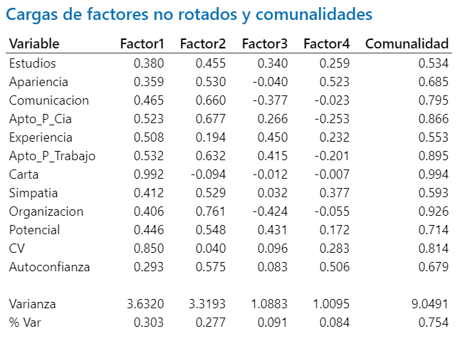

```python
print("Análisis Factorial con Rotación Varimax")
perform_factor_analysis(df, 4,"Varimax")
```

```
Análisis Factorial con Rotación Varimax
```

|  | Factor_1 | Factor_2 | Factor_3 | Factor_4 | Comunalidades |
| --- | --- | --- | --- | --- | --- |
| Estudios | 0.488239 | 0.379952 | 0.123501 | 0.236643 | 0.453993 |
| Apariencia | 0.175087 | 0.716927 | 0.290346 | 0.215606 | 0.675427 |
| Comunicacion | 0.214848 | 0.261439 | 0.790381 | 0.234391 | 0.794152 |
| Apto_P_Cia | 0.781021 | 0.160828 | 0.423915 | 0.191053 | 0.852064 |
| Experiencia | 0.497658 | 0.303794 | -0.069035 | 0.346114 | 0.464515 |
| Apto_P_Trabajo | 0.869247 | 0.187656 | 0.287556 | 0.194420 | 0.911292 |
| Carta | 0.265807 | 0.061491 | 0.222512 | 0.807677 | 0.776289 |
| Simpatia | 0.309123 | 0.674549 | 0.266265 | 0.168628 | 0.649905 |
| Organizacion | 0.227911 | 0.304827 | 0.907727 | 0.062510 | 0.972738 |
| Potencial | 0.663298 | 0.397875 | 0.146346 | 0.181917 | 0.652780 |
| CV | 0.223273 | 0.326189 | 0.098912 | 0.910478 | 0.995004 |
| Autoconfianza | 0.270979 | 0.812682 | 0.192176 | 0.097241 | 0.780270 |
| Varianza | 6.387644 | 1.488465 | 1.104478 | 1.051645 | 10.032232 |
| %Var | 0.318356 | 0.074184 | 0.055046 | 0.052413 | 0.500000 |

[figure not shown]

```python
print("Análisis Factorial con Rotación Quartimax")
perform_factor_analysis(df, 4,"Quartimax")
```

```
Análisis Factorial con Rotación Quartimax
```

|  | Factor_1 | Factor_2 | Factor_3 | Factor_4 | Comunalidades |
| --- | --- | --- | --- | --- | --- |
| Estudios | 0.566400 | 0.217604 | 0.061819 | 0.286377 | 0.453993 |
| Apariencia | 0.334690 | 0.237407 | 0.299335 | 0.646100 | 0.675427 |
| Comunicacion | 0.387212 | 0.223911 | 0.756335 | 0.148458 | 0.794152 |
| Apto_P_Cia | 0.863996 | 0.135207 | 0.295275 | 0.010318 | 0.852064 |
| Experiencia | 0.541883 | 0.323476 | -0.134732 | 0.219290 | 0.464515 |
| Apto_P_Trabajo | 0.932713 | 0.134472 | 0.148008 | 0.036744 | 0.911292 |
| Carta | 0.358245 | 0.785024 | 0.172446 | -0.044143 | 0.776289 |
| Simpatia | 0.452186 | 0.178284 | 0.250974 | 0.592166 | 0.649905 |
| Organizacion | 0.412826 | 0.053087 | 0.873572 | 0.190703 | 0.972738 |
| Potencial | 0.739426 | 0.150464 | 0.056579 | 0.283176 | 0.652780 |
| CV | 0.342771 | 0.906065 | 0.073589 | 0.226146 | 0.995004 |
| Autoconfianza | 0.418487 | 0.118283 | 0.193531 | 0.744106 | 0.780270 |
| Varianza | 6.387644 | 1.488465 | 1.104478 | 1.051645 | 10.032232 |
| %Var | 0.318356 | 0.074184 | 0.055046 | 0.052413 | 0.500000 |

[figure not shown]

Al hacer la comparación, podemos darnos cuenta que los valores de MiniTab y de Python sí cambian, pero las mayores cargas factoriales no, por lo que podemos describir los factores más importantes usando cualquiera, usaremos el de Python. Esto aplicará en todos los casos.

En el Factor 1 las variables más importantes son la Carta y el CV , por lo que lo llamaremos **presentación personal**

En el Factor 2 las variables más importantes son la Comunicación y la Organización , por lo que lo llamaremos **Habilidad de Liderazgo**

En el Factor 3 las variables más importantes son ser Apto para el Trabajo , el Potencial y Apto para Compañía, por lo que lo llamaremos **Capacidad de Trabajo Grupal**

En el Factor 4 las variables más importantes son la Apariencia , la Simpatía y la Autoconfianza, por lo que lo llamaremos **Presentación Personal**

## Ejercicio 2. Inteligencias múltiples y estrategias de autorregulación

Para un estudio sobre Inteligencias Múltiples y estrategias de autorregulación de alumnos se tienen información sobre el nivel de cada uno de 618 alumnos de los primeros semestres en el TecCCM. Los datos son los siguientes:

```python
datos2=pd.read_csv("Datos618AAA.csv")
datos2=datos2.drop(datos2.loc[:,["id","Performance"]],axis=1)
datos2
```

|  | Intra | Inter | LinVerb | Spa | LogMath | Mus | BodKin | Nat | IntMot | ExtMot | FitMood | Anx | SelfReg | SocInt | InfSearch | InfProc |
| --- | --- | --- | --- | --- | --- | --- | --- | --- | --- | --- | --- | --- | --- | --- | --- | --- |
| 0 | 4.8 | 1.0 | 4.5 | 5.0 | 4.4 | 4.5 | 4.0 | 4.8 | 4.6000 | 4.7 | 4.40 | 3.60 | 4.1000 | 2.8000 | 4.600 | 4.9000 |
| 1 | 4.4 | 4.0 | 3.2 | 2.9 | 2.9 | 2.6 | 2.7 | 3.7 | 4.2000 | 2.6 | 4.75 | 4.50 | 3.7895 | 3.3333 | 2.500 | 3.7037 |
| 2 | 5.0 | 4.8 | 4.8 | 3.7 | 4.7 | 3.0 | 3.6 | 4.2 | 4.4000 | 3.2 | 3.75 | 2.50 | 4.1579 | 2.3333 | 4.750 | 4.5926 |
| 3 | 4.1 | 2.8 | 4.5 | 2.8 | 4.1 | 4.0 | 4.0 | 3.8 | 4.8000 | 4.7 | 4.10 | 4.30 | 4.5000 | 3.3000 | 4.200 | 3.7000 |
| 4 | 1.7 | 1.4 | 1.7 | 1.6 | 1.6 | 2.0 | 1.9 | 2.1 | 4.2000 | 4.0 | 4.75 | 4.25 | 3.9474 | 4.5000 | 4.000 | 4.1111 |
| ... | ... | ... | ... | ... | ... | ... | ... | ... | ... | ... | ... | ... | ... | ... | ... | ... |
| 613 | 4.8 | 4.6 | 4.0 | 2.9 | 4.8 | 3.0 | 3.9 | 3.1 | 5.0000 | 2.2 | 3.25 | 3.00 | 3.4737 | 4.6667 | 3.000 | 4.4074 |
| 614 | 4.1 | 3.5 | 3.8 | 3.5 | 4.3 | 3.0 | 3.2 | 3.4 | 4.3333 | 1.8 | 2.50 | 2.00 | 3.2105 | 2.3333 | 3.875 | 3.6296 |
| 615 | 4.5 | 3.9 | 4.0 | 3.8 | 4.3 | 3.6 | 4.2 | 4.1 | 4.3333 | 3.2 | 2.50 | 3.25 | 3.7895 | 3.6667 | 3.375 | 4.1481 |
| 616 | 4.7 | 3.9 | 4.0 | 4.3 | 4.7 | 2.5 | 4.3 | 3.3 | 4.6667 | 2.2 | 4.50 | 2.00 | 3.3684 | 3.1667 | 3.125 | 4.0741 |
| 617 | 4.1 | 4.1 | 3.5 | 2.7 | 4.1 | 2.1 | 3.5 | 3.5 | 4.6000 | 1.6 | 4.00 | 3.25 | 3.4737 | 3.5000 | 3.875 | 3.5926 |

618 rows × 16 columns

Ejecute un Análisis factorial para conocer más sobre las relaciones subyacentes que hay entre las variables considerando 2 y 4 factores tal como de realizó en clase.

### Análisis de 2 factores

```python
print("Análisis Factorial sin Rotación")
perform_factor_analysis(datos2,2,None)
```

```
Análisis Factorial sin Rotación
```

|  | Factor_1 | Factor_2 | Comunalidades |
| --- | --- | --- | --- |
| Intra | 0.685983 | 0.446650 | 0.670070 |
| Inter | 0.313758 | 0.556100 | 0.407691 |
| LinVerb | 0.615826 | 0.522655 | 0.652410 |
| Spa | 0.277298 | 0.576616 | 0.409380 |
| LogMath | 0.653378 | 0.582158 | 0.765811 |
| Mus | 0.446534 | 0.247494 | 0.260646 |
| BodKin | 0.512016 | 0.499892 | 0.512053 |
| Nat | 0.472450 | 0.391457 | 0.376448 |
| IntMot | 0.700852 | -0.407700 | 0.657413 |
| ExtMot | 0.186821 | -0.226595 | 0.086247 |
| FitMood | 0.606730 | -0.273536 | 0.442943 |
| Anx | 0.101856 | -0.230363 | 0.063442 |
| SelfReg | 0.803915 | -0.454119 | 0.852504 |
| SocInt | 0.553972 | -0.265705 | 0.377484 |
| InfSearch | 0.714696 | -0.328139 | 0.618465 |
| InfProc | 0.704210 | -0.289537 | 0.579744 |
| Varianza | 5.508614 | 3.167591 | 8.676205 |
| %Var | 0.317455 | 0.182545 | 0.500000 |

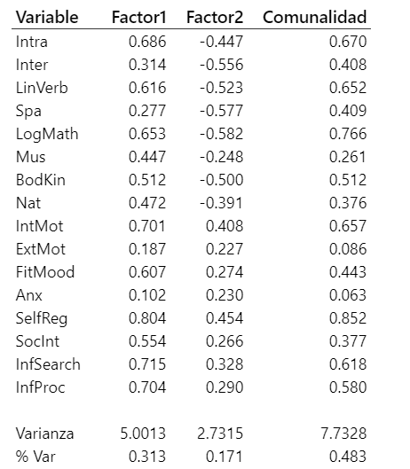

```python
print("Análisis Factorial con Rotación Varimax")
perform_factor_analysis(datos2, 2,"Varimax")
```

```
Análisis Factorial con Rotación Varimax
```

|  | Factor_1 | Factor_2 | Comunalidades |
| --- | --- | --- | --- |
| Intra | 0.778402 | 0.253298 | 0.670070 |
| Inter | 0.629798 | -0.105097 | 0.407691 |
| LinVerb | 0.793485 | 0.150969 | 0.652410 |
| Spa | 0.622864 | -0.146355 | 0.409380 |
| LogMath | 0.863373 | 0.142821 | 0.765811 |
| Mus | 0.473038 | 0.192043 | 0.260646 |
| BodKin | 0.710574 | 0.084483 | 0.512053 |
| Nat | 0.601343 | 0.121796 | 0.376448 |
| IntMot | 0.122906 | 0.801441 | 0.657413 |
| ExtMot | -0.058999 | 0.287691 | 0.086247 |
| FitMood | 0.168196 | 0.643936 | 0.442943 |
| Anx | -0.115293 | 0.223940 | 0.063442 |
| SelfReg | 0.151512 | 0.910795 | 0.852504 |
| SocInt | 0.141155 | 0.597963 | 0.377484 |
| InfSearch | 0.193512 | 0.762246 | 0.618465 |
| InfProc | 0.216966 | 0.729842 | 0.579744 |
| Varianza | 5.508614 | 3.167591 | 8.676205 |
| %Var | 0.317455 | 0.182545 | 0.500000 |

[figure not shown]

```python
print("Análisis Factorial con Rotación Quartimax")
perform_factor_analysis(datos2, 2,"Quartimax")
```

```
Análisis Factorial con Rotación Quartimax
```

|  | Factor_1 | Factor_2 | Comunalidades |
| --- | --- | --- | --- |
| Intra | 0.767915 | 0.283507 | 0.670070 |
| Inter | 0.633422 | -0.080419 | 0.407691 |
| LinVerb | 0.786983 | 0.181845 | 0.652410 |
| Spa | 0.628105 | -0.121916 | 0.409380 |
| LogMath | 0.857137 | 0.176432 | 0.765811 |
| Mus | 0.465177 | 0.210372 | 0.260646 |
| BodKin | 0.706732 | 0.112172 | 0.512053 |
| Nat | 0.596128 | 0.145189 | 0.376448 |
| IntMot | 0.091510 | 0.805629 | 0.657413 |
| ExtMot | -0.070190 | 0.285168 | 0.086247 |
| FitMood | 0.142918 | 0.650014 | 0.442943 |
| Anx | -0.123951 | 0.219267 | 0.063442 |
| SelfReg | 0.115823 | 0.916018 | 0.852504 |
| SocInt | 0.117693 | 0.603020 | 0.377484 |
| InfSearch | 0.163594 | 0.769222 | 0.618465 |
| InfProc | 0.188295 | 0.737759 | 0.579744 |
| Varianza | 5.508614 | 3.167591 | 8.676205 |
| %Var | 0.317455 | 0.182545 | 0.500000 |

[figure not shown]

# Análisis de 4 factores

```python
print("Análisis Factorial sin Rotación")
perform_factor_analysis(datos2,4,None)
```

```
Análisis Factorial sin Rotación
```

|  | Factor_1 | Factor_2 | Factor_3 | Factor_4 | Comunalidades |
| --- | --- | --- | --- | --- | --- |
| Intra | 0.539662 | 0.409783 | 0.505347 | -0.003375 | 0.714545 |
| Inter | -0.018591 | 0.997182 | -0.015260 | 0.007133 | 0.995000 |
| LinVerb | 0.419025 | 0.539082 | 0.433859 | -0.033897 | 0.655575 |
| Spa | 0.031653 | 0.645925 | 0.238498 | -0.123477 | 0.490349 |
| LogMath | 0.458337 | 0.519128 | 0.522750 | -0.186548 | 0.787634 |
| Mus | 0.387169 | 0.162667 | 0.373951 | 0.104778 | 0.327178 |
| BodKin | 0.336692 | 0.455221 | 0.424299 | -0.061819 | 0.504439 |
| Nat | 0.364476 | 0.291935 | 0.462875 | 0.120126 | 0.446752 |
| IntMot | 0.764615 | 0.047466 | -0.326258 | -0.121593 | 0.708118 |
| ExtMot | 0.345596 | -0.355182 | 0.200060 | 0.541815 | 0.579178 |
| FitMood | 0.652149 | 0.016851 | -0.084495 | 0.135834 | 0.451173 |
| Anx | 0.213968 | -0.207202 | 0.021728 | 0.622772 | 0.477032 |
| SelfReg | 0.869810 | 0.005558 | -0.251589 | 0.017298 | 0.820196 |
| SocInt | 0.566752 | 0.171821 | -0.279439 | 0.155738 | 0.453071 |
| InfSearch | 0.795318 | -0.044293 | -0.099635 | -0.031443 | 0.645408 |
| InfProc | 0.706741 | 0.252199 | -0.381202 | -0.128518 | 0.724919 |
| Varianza | 5.508614 | 3.167591 | 1.715936 | 0.849114 | 11.241255 |
| %Var | 0.245018 | 0.140891 | 0.076323 | 0.037768 | 0.500000 |

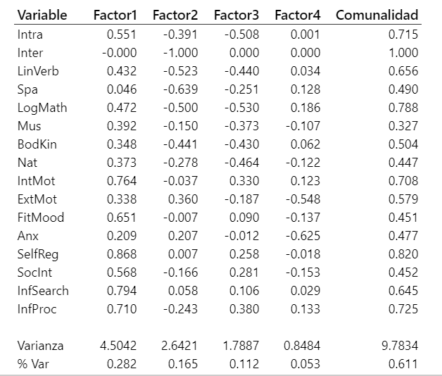

```python
print("Análisis Factorial con Rotación Varimax")
perform_factor_analysis(datos2, 4,"Varimax")
```

```
Análisis Factorial con Rotación Varimax
```

|  | Factor_1 | Factor_2 | Factor_3 | Factor_4 | Comunalidades |
| --- | --- | --- | --- | --- | --- |
| Intra | 0.807245 | 0.236732 | 0.059723 | 0.057379 | 0.714545 |
| Inter | 0.433140 | 0.032981 | -0.264993 | 0.857952 | 0.995000 |
| LinVerb | 0.761964 | 0.175710 | -0.036106 | 0.206900 | 0.655575 |
| Spa | 0.502631 | -0.050851 | -0.248993 | 0.416086 | 0.490349 |
| LogMath | 0.849682 | 0.179386 | -0.153782 | 0.099234 | 0.787634 |
| Mus | 0.520872 | 0.148768 | 0.179643 | -0.038302 | 0.327178 |
| BodKin | 0.684104 | 0.108181 | -0.056843 | 0.146650 | 0.504439 |
| Nat | 0.638931 | 0.089554 | 0.167369 | 0.049864 | 0.446752 |
| IntMot | 0.091550 | 0.835029 | -0.025249 | -0.042726 | 0.708118 |
| ExtMot | 0.101076 | 0.135760 | 0.694521 | -0.261096 | 0.579178 |
| FitMood | 0.202632 | 0.593974 | 0.235239 | -0.044389 | 0.451173 |
| Anx | -0.031945 | 0.108135 | 0.681163 | -0.018312 | 0.477032 |
| SelfReg | 0.165048 | 0.874806 | 0.146050 | -0.079614 | 0.820196 |
| SocInt | 0.083227 | 0.620449 | 0.169488 | 0.180169 | 0.453071 |
| InfSearch | 0.234128 | 0.738179 | 0.120421 | -0.176587 | 0.645408 |
| InfProc | 0.117956 | 0.821218 | -0.104910 | 0.160001 | 0.724919 |
| Varianza | 5.508614 | 3.167591 | 1.715936 | 0.849114 | 11.241255 |
| %Var | 0.245018 | 0.140891 | 0.076323 | 0.037768 | 0.500000 |

[figure not shown]

```python
print("Análisis Factorial con Rotación Quartimax")
perform_factor_analysis(datos2, 4,"Quartimax")
```

```
Análisis Factorial con Rotación Quartimax
```

|  | Factor_1 | Factor_2 | Factor_3 | Factor_4 | Comunalidades |
| --- | --- | --- | --- | --- | --- |
| Intra | 0.804777 | 0.241836 | 0.036992 | 0.083814 | 0.714545 |
| Inter | 0.458128 | 0.003380 | 0.876179 | -0.131973 | 0.995000 |
| LinVerb | 0.765944 | 0.172904 | 0.197229 | 0.010478 | 0.655575 |
| Spa | 0.519058 | -0.069069 | 0.432450 | -0.170715 | 0.490349 |
| LogMath | 0.855837 | 0.174211 | 0.104553 | -0.117881 | 0.787634 |
| Mus | 0.512800 | 0.160151 | -0.069844 | 0.183541 | 0.327178 |
| BodKin | 0.687983 | 0.105530 | 0.140201 | -0.018038 | 0.504439 |
| Nat | 0.633012 | 0.099017 | 0.014659 | 0.189812 | 0.446752 |
| IntMot | 0.089120 | 0.834262 | -0.016737 | -0.062469 | 0.708118 |
| ExtMot | 0.070667 | 0.173350 | -0.350493 | 0.649067 | 0.579178 |
| FitMood | 0.191382 | 0.605826 | -0.063057 | 0.208672 | 0.451173 |
| Anx | -0.057188 | 0.138884 | -0.106021 | 0.665757 | 0.477032 |
| SelfReg | 0.155568 | 0.882911 | -0.076884 | 0.102724 | 0.820196 |
| SocInt | 0.078528 | 0.623525 | 0.171686 | 0.169249 | 0.453071 |
| InfSearch | 0.224127 | 0.747894 | -0.175022 | 0.072090 | 0.645408 |
| InfProc | 0.122173 | 0.812337 | 0.193721 | -0.112131 | 0.724919 |
| Varianza | 5.508614 | 3.167591 | 1.715936 | 0.849114 | 11.241255 |
| %Var | 0.245018 | 0.140891 | 0.076323 | 0.037768 | 0.500000 |

[figure not shown]

# Análisis de Variables

En este caso, sí hubo bastantes casos diferentes, pues pasó que en Python el signo era diferente al de MiniTab, además de que en muchos las variables importantes en cada factor cambian, así que haré la comparación

- 2 factores
- Sin Rotacion

Python

Factor 1: Intra + LinVerb + LogMath + IntMot + FitMood + SelfReg + Inf Search + InfProc [Factor de Autorregulación y Procesamiento Interno] Factor 2: Spa + LogMath (Habilidad Matemática-Linguística)

MiniTab

En este caso ambos programas generan factores parecidos

- 2 factores
- Rotación VariMax

Python

Factor 1: Intra + Inter + LinVerb + Spa + LogMath + BodKin (Factor de Procesamiento Espacial) Factor 2: IntMot + FitMood + SelfReg + SocInt+ InfSearch + InfProc (Factor de Autonomía Emocional y Procesamiento Social e Interno)

MiniTab

Factor 1: Intra + LinVerb + LogMath + IntMot + FitMood+ SelfReg ("Factor de Habilidades Cognitivas y Emocionales Internas) Factor 2: Es muy parecido a Python pero son signos contrarios

- 2 factores
- Rotación QuartiMax

En los demás el parecido es bastante y no hay necesidad de compararlos